# Week 02 — FastQC and Trimming

Author

Abby Farr

Published

October 5, 2026

## 1. This week’s analysis: Trimming

1. Commands or code used for read counts and QC.

> curl -O to read in file from a website, gunzip to unzip fastq file, head to look at the first few rows to insepct the data, FastQC-0.12.1/fastqc to run a fastq on the downloaded data file.
2. A small table of samples and read counts.

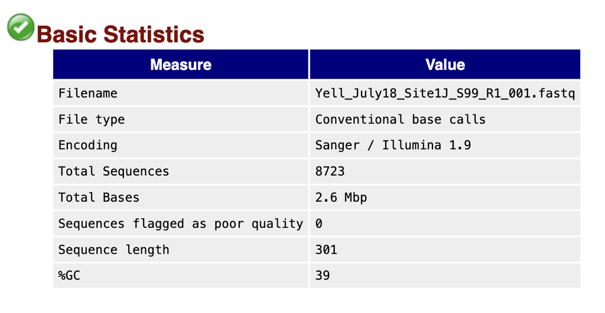

3. Before and after QC evidence if trimming was performed.

## 2. Reflection questions

1. What does a per-base quality plot tell you, and what does it not tell you?

> A per-base quality plot tells us what the quality of the reads are, it can not tell you if there is contaminatin in the read or why a read is poor quality. Even if the read is still good quality there could be something off with the read.
2. When is trimming useful, and when might it remove useful information?

> Trimming is useful when you have a primer that you need to get rid of or if you have bad quality reads that you do not want to use in your analysis. It might be remove useful information if you trim too much or if you do not know what you are trimming out.
3. For your project, name the raw input format, the first QC step, and the first downstream analysis step.

> The raw input formats for my data are fastq files from the nightingale server, the first QC step is to run a fast qc report and then trim sequences that are poor quality or basebairs that are not consistant with the rest of the sequence.

## 3. Project progress

> Using eDNA data on nightingales from Yellow Island in 2023. I have uploaded the data into raven and ran a fastQC in it.

## 4. Where I’m stuck

> None

## 5. Next week

> My goal for next week is to assemble the eDNA and make sure any trimming steps are complete.